# Session 1: Introduction

ESS: Introduction to Web Scraping and Data Management for Social Scientists

Johannes B. Gruber

2026-07-20

# Introduction

## This Course

| Day | Session |
| --- | --- |
| 1 | Introduction |
| 2 | Data Structures and Wrangling |
| 3 | Working with Files |
| 4 | Linking and joining data & SQL |
| 5 | Scaling, Reporting and Database Software |
| 6 | Introduction to the Web |
| 7 | Static Web Pages |
| 8 | Application Programming Interface (APIs) |
| 9 | Interactive Web Pages |
| 10 | Building a Reproducible Research Project |

General Goals:

- I want to teach you web scraping and data management
- I also want to give you the tools for *reproducible* and *transparent* open science research

## The Plan for Today

In this session, you learn how to use the **tools** of the hunt. We will:

- learn about:
  1. each other
  2. the course material and structure
- go over some principles of using the programming language `R`:
  - `R` Refresher
  - literate programming
- wrap up with some useful tools, tips and tricks

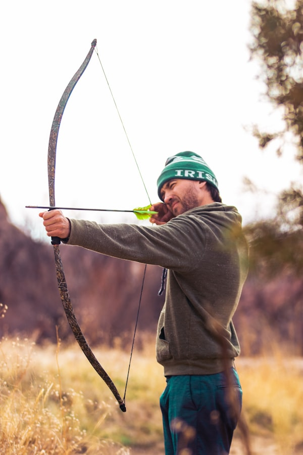

[Woody Kelly](https://unsplash.com/@woodkell) via unsplash.com

## Who am I?

- Senior Researcher/Team Lead in Data Services for the Social Sciences @ GESIS
- Previously PostDoc in Communication at VU Amsterdam, University of Amsterdam, and European New School of Digital Studies
- Interested in:
  - Computational Social Science
  - Open and reproducible science
  - Automated Content Analysis
  - Hybrid Media Systems and Information Flows
  - Protest and Democracy
- Experience:
  - R user since 2015
  - R package developer since 2017
  - Worked on several packages for text analysis, API access and web scraping (spacyr, quanteda.textmodels, LexisNexisTools, paperboy, traktok, rollama, amcat4-r, atrrr, rwhatsapp and more)

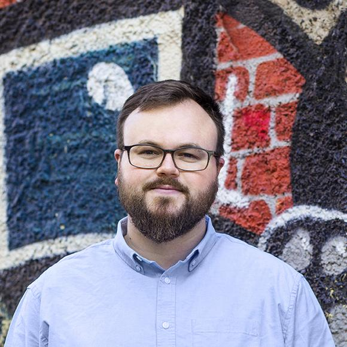

Contact:

- (during the course) jg23824@essex.ac.uk
- johannes.gruber@gesis.org
- [@jbgruber.bsky.social](https://bsky.app/profile/jbgruber.bsky.social)